# Online Point Process Simulations

# Homogeneous Poisson

## Parameter Recovery from data simulated from the model

We first simulate some data from our proposed model with a homogeneous Poisson process describing interactions.

```r
Time = 50
dT = 0.1
K <- 3
Mu <- matrix(c(0.6,0.2,0.3,0.1,1.0,0.4,0.5,0.4,0.8),K,K,byrow = TRUE)
B_Pois <- matrix(0,K,K,byrow = TRUE)
m <- 100
Pi <- matrix(c(0.4,0.3,0.3),1,3)
Z <- c(rep(0,m*Pi[1]),rep(1,m*Pi[2]),rep(2,m*Pi[3]))

A <- list()
for(i in 1:m){
  # could sample these here with SBM structure...
  edge <- sample(m, 40) - 1
  edge <- sort(edge)
  A[[i]] <- edge
}

system.time(alltimes <- sampleBlockHak(Time, A, Z, Mu, B_Pois, lam = 1))
```

We then aim to recover these parameters using our proposed model.

Up to label switching, our model successfully recovers the true parameters and latent groups. This is of course somewhat dependent on the random initialization.

```r
results_online$B
```

```
          [,1]      [,2]      [,3]
[1,] 1.0262805 0.1183033 0.3986013
[2,] 0.2136535 0.6136416 0.2873823
[3,] 0.4110438 0.5020461 0.8468916
```

```r
Mu
```

```
     [,1] [,2] [,3]
[1,]  0.6  0.2  0.3
[2,]  0.1  1.0  0.4
[3,]  0.5  0.4  0.8
```

We can also examine how our model approaches this solution, by examining the average ELBO per event. We see that it correctly learns the group labels present in the data also.

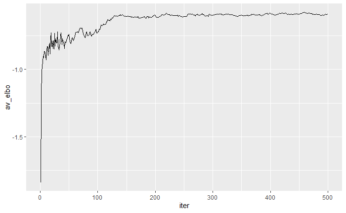

```r
library(ggplot2)
iter = c(1:500)
av_elbo = results_online$AveELBO
ll = results_online$logL
elbo = as_tibble(cbind(iter,av_elbo,ll))
ggplot(data = elbo, aes(iter,av_elbo)) + geom_line()
```

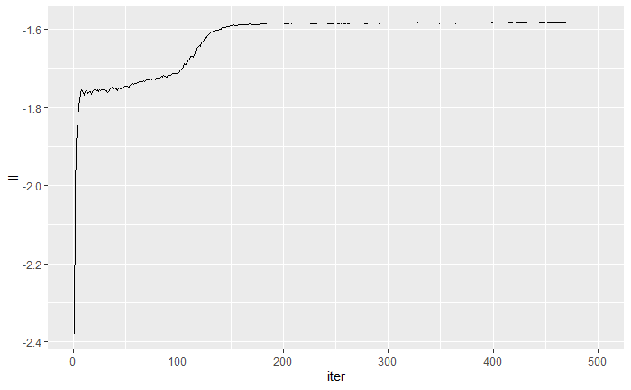

```r
ggplot(data = elbo, aes(iter,ll)) + geom_line()
```

```r
est_Z = apply(results_online$tau,1,which.max)
adjustedRandIndex(Z,est_Z)
```

```
[1] 1
```

```r
aricode::NMI(Z,est_Z)
```

```
[1] 1
```

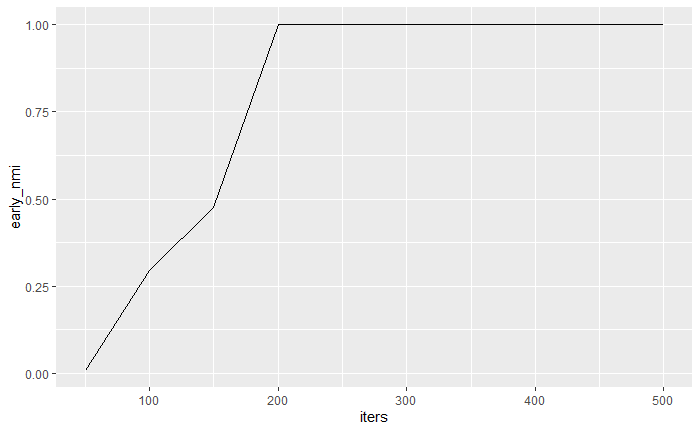

```r
# this plot was working better before but not now...
time_points = dim(results_online$early_tau)[3]
early_nmi = rep(0,time_points)
for(i in 1:time_points){
  est_Z = apply(results_online$early_tau[,,i],1,which.max)
  early_nmi[i]= aricode::NMI(Z,est_Z)
}
online_nmi = cbind(iters = seq(50,500,50),early_nmi)
as_tibble(online_nmi) %>% ggplot(aes(iters,early_nmi)) + geom_line()
```

## Comparison to existing methods

We can also fit the model in `ppsbm` to this data.

```r
n_events = dim(alltimes)[1]
ids = rep(0,n_events)
times = rep(0,n_events)
m = 100
A_matrix = matrix(0,nrow = m,ncol = m)
A_mat_bin = matrix(0,nrow = m,ncol = m)
for(i in 1:n_events){
  j = alltimes[i,1]+1
  k = alltimes[i,2]+1
  ids[i] = convertNodePair(j,k,m,TRUE)
  times[i] = alltimes[3]
  A_matrix[j,k] = A_matrix[j,k] + 1
  A_mat_bin[j,k] = 1
}
sim_data = list(time.seq = times, type.seq = ids, Time = Time)
Dmax = 2^3
Nijk = statistics(sim_data,Dmax,n=m,directed = T)
results_ppsbm = ppsbm::mainVEM(list(Nijk=Nijk,Time = 50), n = m, Qmin = 3, Qmax = 3,
                               method = 'hist',directed = T,d_part = 1, n_perturb = 1)
```

```
----increasing Q---- 3
----run---- 1
iteration 1
iteration 2
values of d: 8 8 8 8 8 8 8 8 8
value of J: -42070.01
----run---- 2
iteration 1
iteration 2
values of d: 8 8 8 8 8 8 8 8 8
value of J: -48200.44
----run---- 3
iteration 1
iteration 2
values of d: 8 8 8 8 8 8 8 8 8
value of J: -42070.01
----run---- 4
iteration 1
iteration 2
values of d: 8 8 8 8 8 8 8 8 8
value of J: -49827.45
```

```r
#results[[2]]$tau
est_Z_ppsbm = apply(results_ppsbm[[1]]$tau, 2, which.max)
#est_Z_ppsbm
adjustedRandIndex(Z,est_Z_ppsbm)
```

```
[1] 0.827957
```

This model appears to largely identify the true clusters present in the data.

### Data Simulated from Other Models

We can also compare our results to simulated data included in the `ppsbm` package. This allows data to be simulated for a given parametric form of the intensity function. We consider the following simulation.

```r
prop.groups <- c(0.5,0.5)
# 3 different intensity functions :
intens <- list(NULL)
intens[[1]] <- list(intens= function(x) 100*x*exp(-8*x),max=5)
# (q,l) = (1,1)
intens[[2]] <- list(intens= function(x) exp(3*x)*(sin(6*pi*x-pi/2)+1)/2,max=13)
# (q,l) = (1,2)
intens[[3]] <- list(intens= function(x) 8.1*(exp(-6*abs(x-1/2))-.049),max=8)
# (q,l) = (2,2)
intens[[4]] <- list(intens= function(x) 1.1*(exp(-2*abs(x-1/2))-.1),max=3)
obs <- generateDynppsbm(intens,Time=1,n=50,prop.groups,directed=T)
```

We can readily fit both the Poisson and Hawkes online updates to this data.

We can see that the Hawkes model is able to recover the clusters with this intensity function while the Poisson is not.

```r
true_Z = apply(obs$z,2,which.max)
est_Z_online_Poisson = apply(results_online$tau,1,which.max)
adjustedRandIndex(est_Z_online_Poisson,true_Z)
```

```
[1] -0.01925255
```

```r
est_Z_online_H = apply(results_hawkes$tau,1,which.max)
adjustedRandIndex(est_Z_online_H,true_Z)
```

```
[1] 0.9195971
```

```r
results = mainVEM(data = obs$data, n = 50, Qmin = 2, Qmax = 2, method = 'kernel',
                  directed = T,
                  d_part = 1, n_perturb = 1)
```

```
----increasing Q---- 2
----run---- 1
iteration 1
iteration 2
value of J: 367.4023
----run---- 2
iteration 1
iteration 2
value of J: -448.7243
----run---- 3
iteration 1
iteration 2
value of J: -1396.168
----run---- 4
iteration 1
iteration 2
value of J: -1490.931
----run---- 5
iteration 1
iteration 2
value of J: 367.4023
----run---- 6
iteration 1
iteration 2
value of J: -453.9367
```

```r
est_Z = apply(results[[1]]$tau, 2, which.max)
adjustedRandIndex(true_Z,est_Z)
```

```
[1] 1
```

# Hawkes Process

We also consider a model where the intensity pair is assumed to be a Hawkes process with exponential kernel.

## Parameter Recovery

We first simulate data from a Hawkes process with an exponential kernel and demonstrate parameter recovery in our model in this setting.

```r
Time = 50
dT = 0.1
K <- 3
Mu_H <- matrix(c(0.6,0.2,0.3,0.1,1.0,0.4,0.5,0.4,0.8),K,K,byrow = TRUE)
B_H <- matrix(c(0.8,0.2,0.1,0.15,0.75,0.25,0.1,0.25,0.9),K,K,byrow = TRUE)
m <- 50
Pi <- matrix(c(0.4,0.3,0.3),1,3)
Z <- c(rep(0,m*Pi[1]),rep(1,m*Pi[2]),rep(2,m*Pi[3]))
A <- list()
for(i in 1:m){
  # could sample these here with SBM structure...
  edge <- sample(m, 15) - 1
  edge <- sort(edge)
  A[[i]] <- edge
}
system.time(alltimes_hawkes <- sampleBlockHak(Time, A, Z, Mu_H, B_H, lam = 1))
```

```
m: 50   user  system elapsed
   1.44    0.01    1.49
```

```r
Pi = rep(1/K,K)
Mu = matrix(runif(K*K),K,K)
B = matrix(runif(K*K),K,K)
diag(B) = rnorm(3,mean = 1, sd = 0.1)
tau = matrix(runif(m*K),nrow=m,ncol=K)
tau = tau/rowSums(tau)
S = matrix(0,nrow = m,ncol = K)
results_hawkes_sim <- online_estimator(alltimes_hawkes, A, m, K, Time, dT=0.2, lam = 1, B, Mu, tau,is_elbo = T)
```

```r
results_hawkes_sim$Mu
```

```
          [,1]       [,2]      [,3]
[1,] 0.0997178 0.22260009 0.1852406
[2,] 0.3289392 0.07877375 0.2226328
[3,] 0.2005064 0.22756639 0.1197284
```

```r
Mu_H
```

```
     [,1] [,2] [,3]
[1,]  0.6  0.2  0.3
[2,]  0.1  1.0  0.4
[3,]  0.5  0.4  0.8
```

```r
results_hawkes_sim$B
```

```
          [,1]      [,2]      [,3]
[1,] 0.9727614 0.8326490 0.8067497
[2,] 0.7634736 0.9159399 0.9905567
[3,] 0.9461354 0.8730895 0.9880485
```

```r
B_H
```

```
     [,1] [,2] [,3]
[1,] 0.80 0.20 0.10
[2,] 0.15 0.75 0.25
[3,] 0.10 0.25 0.90
```

```r
adjustedRandIndex(Z,apply(results_hawkes_sim$tau,1,which.max))
```

```
[1] 0.09307441
```

We can also inspect the ELBO for this model

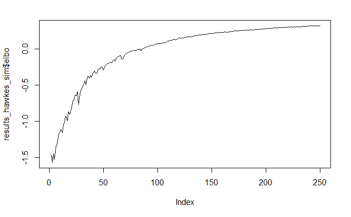

```r
plot(results_hawkes_sim$elbo,type='l')
```

This model seems to not as clearly identify the correct parameters or the latent groups, likely due to the initialisation.